# Predicting Toyota Corolla Price

Homework 1

Mustafa Kaan Aslan

## Toyota Corolla Data Set

Toyota Corolla data set consists of 1436 observations which shows features of the cars such as age, fuel type or price. In this assignment, price will be the output variable and it will be predicted with different models depending on the numerical and categorical attributes.

```r
data <- fread("C:/Users/kaan9/OneDrive/Masaüstü/ToyotaCorolla.csv",
              colClasses=list(numeric=c(1,2,3,5,8,10),factor=c(4,6,7,9)))
```

### 1.a) Splitting the Data Set

The data should be split in to test and training data sets. The training data set consists of 70% of the observations, which is approximately 1005 observations, while the test data set consists of 431. Splitting is completely random.

```r
set.seed(425)
train <- sample(1:1436,1005)
train_dt <- data[train,]
test_dt <- data[-train,]
```

### 1.b) RandomForest Model

```r
control1 <- trainControl(method="repeatedcv",
                        number=10,
                        repeats=5)
models <- list()
for(ntree in (1:5)*100){
    model <- train(Price ~ .,
                data = train_dt,
                method = 'rf',
                metric = 'RMSE',
                trControl = control1,
                tuneGrid = expand.grid(.mtry=1:9),
                ntree=ntree)
    models[[toString(ntree)]] <- model
}
```

```r
models
```

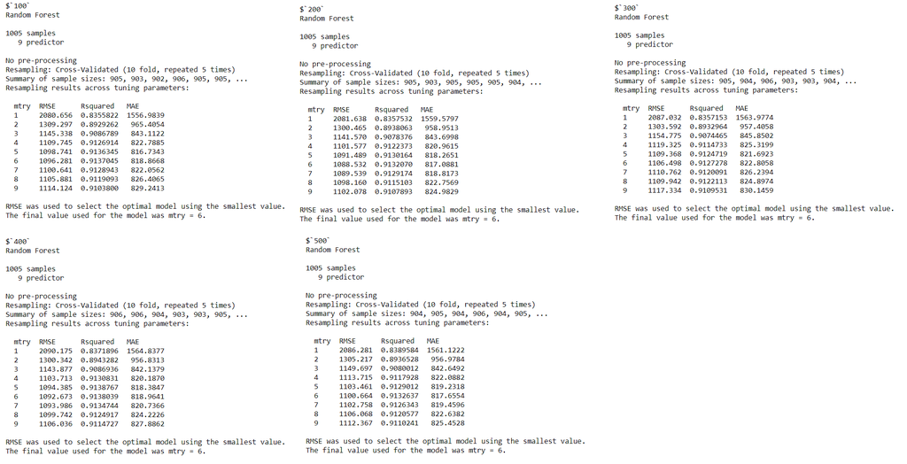

To find the best parameters, CARET package is used. After the tuning process, the best tree in terms of the RMSE is the one with ntree=200 and mtry=6. The lowest RMSE score for these parameters ,which is obtained by repeated cross-validation, is 1088.532. With the randomForest package, the model with ntree=200 and mtry=6 parameters is constructed and applied in test data set to evaluate the performance.

```r
model_opt <- randomForest(Price~.,
                          data=train_dt,
                          mtry=6,
                          ntree=200,
                          importance=TRUE)
prediction <- predict(model_opt,newdata=test_dt)
RMSE_rf <- (sum((test_dt$Price-prediction)^2)/length(prediction))^0.5
round(RMSE_rf,3)
```

1077.616

The optimum model has the RMSE of 1077.616.

### 1.c) Variable Importance

```r
importance_dt <- data.frame(model_opt$importance)
importance_dt[order(importance_dt$IncNodePurity,decreasing=TRUE),]
```

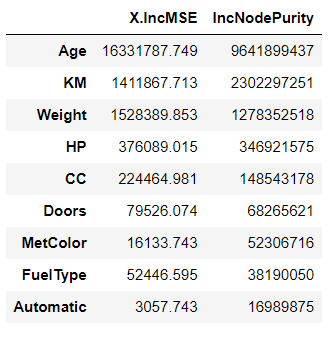

### 1.d) Comparision with Linear Regression Model

```r
model_reg <- lm(Price~.,data=train_dt)
predict_reg <- predict(model_reg,newdata=test_dt)
RMSE_reg <- (sum((test_dt$Price-predict_reg)^2)/length(predict_reg))^0.5
round(RMSE_reg,3)
round((RMSE_reg-RMSE_rf)/RMSE_rf*100,2)
```

1423.096

32.06

The linear regression model has RMSE of 1423.096. The RMSE of the linear regression model is 32.06% higher than the Random Forest model which means Random Forest model is a significantly better model.

### 2) Gradient Boosting Machines

```r
control2 <- trainControl(method="repeatedcv",
                        number=10,
                        repeats=5)
grid <- expand.grid(interaction.depth = c(3:5),
                        n.trees = (3:6)*25,
                        shrinkage = (1:3)*0.1,
                        n.minobsinnode = c(1:3)*5)
model_gbm <- train(Price ~ .,
                data = train_dt,
                method = 'gbm',
                metric = 'RMSE',
                trControl = control2,
                tuneGrid = grid)
model_gbm
```

```
Stochastic Gradient Boosting

1005 samples
   9 predictor

No pre-processing
Resampling: Cross-Validated (10 fold, repeated 5 times)
Summary of sample sizes: 904, 904, 904, 906, 906, 904, ...
Resampling results across tuning parameters:

  shrinkage  interaction.depth  n.minobsinnode  n.trees  RMSE      Rsquared
  0.1        3                   5               75      1130.334  0.9085235
  0.1        3                   5              100      1125.085  0.9094134
  0.1        3                   5              125      1123.139  0.9096858
  0.1        3                   5              150      1122.558  0.9097338
  0.1        3                  10               75      1142.803  0.9065004
  0.1        3                  10              100      1133.570  0.9079417
  0.1        3                  10              125      1130.511  0.9083393
  0.1        3                  10              150      1125.363  0.9090157
  0.1        3                  15               75      1154.316  0.9048929
  0.1        3                  15              100      1147.687  0.9060320
  0.1        3                  15              125      1146.983  0.9061757
  0.1        3                  15              150      1143.718  0.9065881
  0.1        4                   5               75      1124.348  0.9095153
  0.1        4                   5              100      1118.311  0.9103542
  0.1        4                   5              125      1118.102  0.9103187
  0.1        4                   5              150      1118.821  0.9102826
  0.1        4                  10               75      1134.633  0.9080127
  0.1        4                  10              100      1128.462  0.9089322
  0.1        4                  10              125      1123.885  0.9094644
  0.1        4                  10              150      1123.407  0.9095226
  0.1        4                  15               75      1153.308  0.9052260
  0.1        4                  15              100      1149.720  0.9057029
  0.1        4                  15              125      1148.912  0.9058053
  0.1        4                  15              150      1149.923  0.9055354
  0.1        5                   5               75      1114.655  0.9110977
  0.1        5                   5              100      1112.587  0.9113421
  0.1        5                   5              125      1112.654  0.9111180
  0.1        5                   5              150      1110.212  0.9114358
  0.1        5                  10               75      1132.716  0.9084331
  0.1        5                  10              100      1129.355  0.9088842
  0.1        5                  10              125      1123.400  0.9096848
  ...        ...                ...             ...       ....       ....

RMSE was used to select the optimal model using the smallest value.
The final values used for the model were n.trees = 150, interaction.depth =
 5, shrinkage = 0.1 and n.minobsinnode = 5.
```

After the tuning of the parameters, the lowest cross-validation RMSE is 1110.212 with the parameters ntree=150, interaction.depth=5 n.minobsinnode=5 and shrinkage = 0.1.

```r
model_opt_gbm <- gbm(Price~.,
                     data=train_dt,
                     n.trees = 150,
                     interaction.depth = 5,
                     n.minobsinnode = 5,
                     shrinkage = 0.1)
predict_gbm <- predict(model_opt_gbm,newdata=test_dt)
RMSE_gbm <- (sum((test_dt$Price-predict_gbm)^2)/length(predict_gbm))^0.5
round(RMSE_gbm,3)
```

1058.501

The predictions obtained with the optimum GBM model and it has RMSE of 1058.501. It could be concluded that for the predictions of the Toyota Corolla prices, Gradient Boosting Machines and Random Forest models have the similar error rates and both of them are significantly better than the linear regression model.